# 2 - Reportes con targets

## Usando funciones de `tarchetypes`

En nuestro primer pipeline incluimos el código para obtener y limpiar los datos. Ahora obtendremos el total de recetas por país, el promedio de tiempo de preparación, la evaluación promedio y el total de evaluaciones por país. Finalmente, utilizaremos la salida de nuestro pipeline en un reporte de Quarto.

Los creadores de `targets` también desarrollaron un paquete complementario llamado `tarchetypes` con funciones útiles para facilitar ciertas tareas comunes en los flujos de datos.

Una de estas funciones es `tar_plan()`, con la que podemos definir los targets de forma más compacta, similar a como lo haríamos en un script tradicional de R.

Nuestro nuevo archivo `_targets.R` con `tar_plan()` se vería así:

```r
library(targets)
library(tarchetypes)
library(readr)
library(dplyr)

limpiar_datos <- function(data) {
  data |>
    filter(
      !is.na(total_ratings) &
        !is.na(avg_rating) &
        !is.na(total_time) &
        total_time > 5 &
        total_time < 300
    ) |>
    select(name, country, total_time, avg_rating, total_ratings)
}

resumir_datos <- function(data) {
  data |>
    group_by(country) |>
    summarise(
      recetas = n(),
      tiempo_promedio = mean(total_time, na.rm = T),
      evaluacion_promedio = mean(avg_rating, na.rm = T),
      numero_evaluaciones = sum(total_ratings)
    )
}

tar_plan(
  recetas_raw = read_csv(
    "https://raw.githubusercontent.com/rfordatascience/tidytuesday/main/data/2025/2025-09-16/cuisines.csv"
  ),
  recetas = limpiar_datos(recetas_raw),
  recetas_resumen = resumir_datos(recetas)
)
```

Ejecuta el pipeline y lee el objeto `recetas_resumen` para verificar que todo esté correcto.

## Trabajando con archivos de entrada

¿Qué pasa cuándo los datos no se encuentran en la web, sino en archivos locales?

En un proyecto de `targets`, el lugar adecuado para almacenar datos es en la carpeta `_targets/user/data/`. Si esta no existe, puedes crearla manualmente. Descarga el archivo de datos y guárdalo en esa ubicación con el nombre `recetas.csv`.

Modificaremos nuestro `tar_plan()` para leer los datos desde ese archivo local, usando nuevamente la función `read_csv()` de `readr`:

```r
tar_plan(
  recetas_raw = read_csv(
    "_targets/user/data/recetas.csv"
  ),
  recetas = limpiar_datos(recetas_raw),
  recetas_resumen = resumir_datos(recetas)
)
```

Corre el pipeline nuevamente.

Si por alguna razón cambia el contenido del archivo de datos, ¿crees que `targets` detectará el cambio y volverá a ejecutar el pipeline correctamente?

**Pruébalo tú mismo**

Puedes intentarlo eliminando filas en el archivo `recetas.csv`, solo asegúrate de guardar una copia de respaldo antes.

Una vez que el target `recetas_raw` es creado, `targets` no es capaz de detectar ningún cambio en el archivo original, ya que lo que se monitorea es el objeto en memoria.

Para incluir el archivo como una dependencia en nuestro flujo de datos, podemos usar la función `tar_file_read()`. Esta función es parte de un grupo de funciones en `tarchetypes` llamadas fábricas de targets.

En particular, `tar_file_read()` genera un target para el archivo y otro target para leer su contenido, asegurando que `targets` monitoree cualquier cambio en el archivo.

```r
tar_plan(
  tar_file_read(
    recetas_raw,
    "_targets/user/data/recetas.csv",
    read_csv(!!.x)
  ),
  recetas = limpiar_datos(recetas_raw),
  recetas_resumen = resumir_datos(recetas)
)
```

Ahora, si haces cambios en el archivo `recetas.csv`, `targets` detectará el cambio y volverá a ejecutar el pipeline correctamente. ¡Inténtalo!

## Generando archivos de salida

Imaginemos que queremos guardar el resumen de recetas por país en un archivo CSV para compartirlo con nuestro equipo de trabajo.

Podemos usar la función `tar_file()` de `tarchetypes` para crear un target que genere este archivo de salida. Sin embargo, para que `targets` pueda monitorear el archivo correctamente, necesitamos escribir una función que regrese el nombre del archivo generado, cosa que `write_csv` no hace por default.

```r
guardar_archivo <- function(data, archivo) {
  write_csv(data, archivo)
  return(archivo)
}

tar_plan(
  tar_file_read(
    recetas_raw,
    "_targets/user/data/recetas.csv",
    read_csv(!!.x)
  ),
  recetas = limpiar_datos(recetas_raw),
  recetas_resumen = resumir_datos(recetas),
  tar_file(
    archivo_recetas_resumen,
    guardar_archivo(
      recetas_resumen,
      archivo = "_targets/user/data/recetas_resumen.csv"
    )
  )
)
```

Corre el pipeline nuevamente y verifica que el archivo `recetas_resumen.csv` se haya creado en la carpeta `_targets/user/data/`. En este caso guardamos el archivo en `data/` pero podríamos guardarlo en otra ubicación.

**¿Cómo se ve el gráfico de dependencias ahora?**

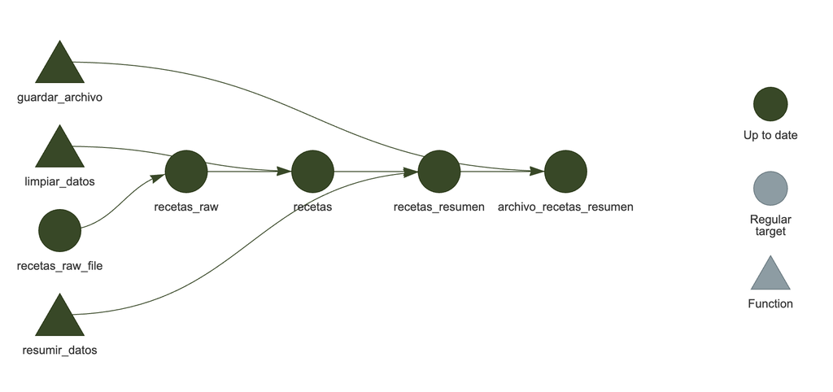

Gráfico de dependencias

## Generando reportes con Quarto

Una vez que tenemos los resultados de nuestro análisis, podemos crear reportes dinámicos utilizando Quarto. En ellos podemos incluir gráficos y tablas para compartir nuestros resultados.

La ventaja de este enfoque es que separamos la capa del análisis y la capa de presentación, lo que facilita la actualización y mantenimiento de ambos componentes.

Para este ejemplo, tenemos un reporte llamado `reporte_recetas.qmd` en la carpeta `reportes` que utiliza los resultados generados por nuestro pipeline de `targets`.

Añadimos el reporte a nuestro archivo `_targets.R` utilizando la función `tar_quarto()` de `tarchetypes`.

```r
tar_quarto(
  reporte_recetas,
  path = "reportes/reporte_recetas.qmd"
)
```

Y del lado del archivo `.qmd`, necesitamos especificar que cargaremos el target `recetas_resumen` para utilizar sus datos.

Esto lo hacemos añadiendo una celda de código al inicio del reporte:

```r
targets::tar_load(
  recetas_resumen
)
```

Ahora, al ejecutar el pipeline, `targets` generará automáticamente el reporte utilizando los datos más recientes.

Realiza algunas modificaciones al reporte y corre nuevamente el pipeline. ¿El reporte se actualiza correctamente con los nuevos cambios?

## Resumen

- Utilizamos `tarchetypes` para simplificar la definición de targets en nuestro pipeline.
- Definimos targets para el análisis de datos, lectura y escritura de archivos, y generación de reportes.
- Integramos Quarto con `targets` para crear reportes dinámicos basados en los resultados del análisis.
- El archivo `_targets.R` que hemos generado en esta notebook lo encuentras como: `_targets2.R`